# V506 Lab 4

User written functions and data summaries

Luis Navarro

Fall 2024

# Readings for this lab

- [R Cookbook](https://rc2e.com/) Chapter 8, Chapter 10, Chapter 15 (Complete)
- [R for Data Science](https://r4ds.hadley.nz/) Chapter 3, 25, 26 (Complete)
- [The Epidemiologist R Handbook](https://epirhandbook.com/en/) Chapter 11, 13 (Complete).

# Setup: Clean Environment and Load Libraries

```r
# Clean the environment
rm(list=ls())

# Set your working directory
setwd("/Users/luisenriquenavarro/Library/CloudStorage/OneDrive-IndianaUniversity/V506/Fall24/Lab4")

# Packages Required for the session
library(pacman)
p_load(dplyr, ggplot2, rmarkdown, rio, here)
```

# Functions in R

- We have explored several functions from base R and from specific packages.
- We can create our own functions too!
- Function structure: relationship between *inputs* and *outputs* through a rule of correspondence (program).
- Recall math intuition. Let $y$ be a function $f$ of $x$.

$$\begin{equation*}
y = f(x)
\end{equation*}$$

- Function (program) $f$ transforms input $x$ on output $y$.
- Function syntax in R

```r
functionName = function(inputs) {
< function body >
return(value)
}
```

# Functions: Example 1

- Example: Linear Function:

$$\begin{equation*}
y = 1 + 2x
\end{equation*}$$

- In words: take $x$, multiply it by 2, and add 1. (Note: order of operations matter)

```r
line_function <- function(x){
  y = 1 + 2*x
  return(y)
}
```

- Parameters (Input): x.
- Output: y

```r
x1 <- 5
y1 <- line_function(x1)
print(c(x1,y1))
```

```
## [1]  5 11
```

- You can apply some functions to vectors.

```r
seq_x <- c(1:100)
seq_y <- line_function(seq_x)

# Show data in data frame
data_line <- data.frame(x = seq_x, y = seq_y)
data_line %>% head(n=10)
```

```
##     x  y
## 1   1  3
## 2   2  5
## 3   3  7
## 4   4  9
## 5   5 11
## 6   6 13
## 7   7 15
## 8   8 17
## 9   9 19
## 10 10 21
```

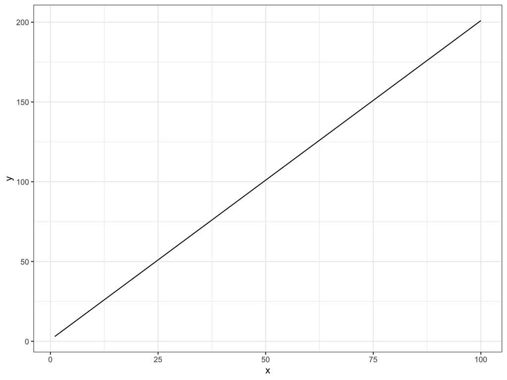

```r
# show graph using ggplot
ggplot(data = data_line, mapping = aes(x = x,y = y)) +
       geom_line(col="black") +
  theme_bw()
```

# Functions: Example 2

- Functions can have more than one parameters.
- Recall the general form of the linear function: $b$ is the intercept, $m$ is the slope, and $x$ is the data.

$$\begin{equation*}
y = b + mx
\end{equation*}$$

```r
line_function1 <- function(x,b,m){
  y = b + m*x
  return(y)
}
```

- **Example:** let $b=10$ and $m=-2$.

```r
data_line2 <- data.frame(x = seq_x,
                         y = line_function1(x = seq_x, b = 10, m = -2))

data_line2 %>% head(n=5L)
```

```
##   x y
## 1 1 8
## 2 2 6
## 3 3 4
## 4 4 2
## 5 5 0
```

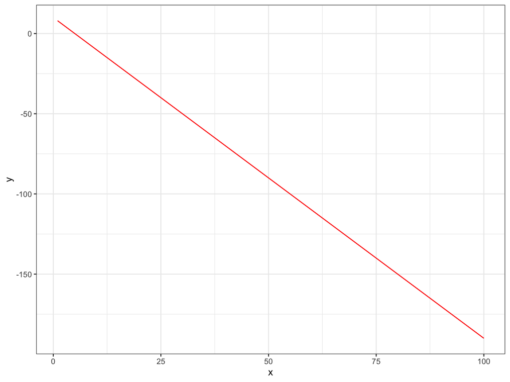

```r
ggplot(data = data_line2, mapping = aes(x = x,y = y)) +
       geom_line(col="red")+ theme_bw()
```

# Simulating Random Variables

- Statistical analysis requires understanding how probability distributions work.
- For that, we will cover how to simulate them using R.
- For simplicity, we will only work with the normal distribution.

# Example: Simulating a Normal Distribution

- Let’s create a function that takes a random sample from a normal distribution.
- Parameters: number of observations, and the moments of the distribution (mean and standard deviation)

```r
create_random_normal <- function(n, mean, sd) {
  set.seed(1234)
  # Take a sample of n observations from a normal distribution with mean and sd
  random_sample <- rnorm(n = n, mean = mean, sd = sd)
  # Obtain the density of the sample we just simulated
  normal_density <- dnorm(random_sample, mean = mean, sd = sd)
  # Save the output in a data frame
  df <- tibble(id = seq(1:n),
               values = random_sample,
               density = normal_density)
  return(df)
}
```

- Use the function to simulate 1000 draws from a normal distribution with mean = 1 and sd = 2

```r
sample1 <- create_random_normal(n = 1000,
                                mean = 1,
                                sd = 2)

sample1 %>% head()
```

```
## # A tibble: 6 × 3
##      id values density
##   <int>  <dbl>   <dbl>
## 1     1  -1.41  0.0963
## 2     2   1.55  0.192
## 3     3   3.17  0.111
## 4     4  -3.69  0.0127
## 5     5   1.86  0.182
## 6     6   2.01  0.175
```

- Visualize this using a ggplot graph.

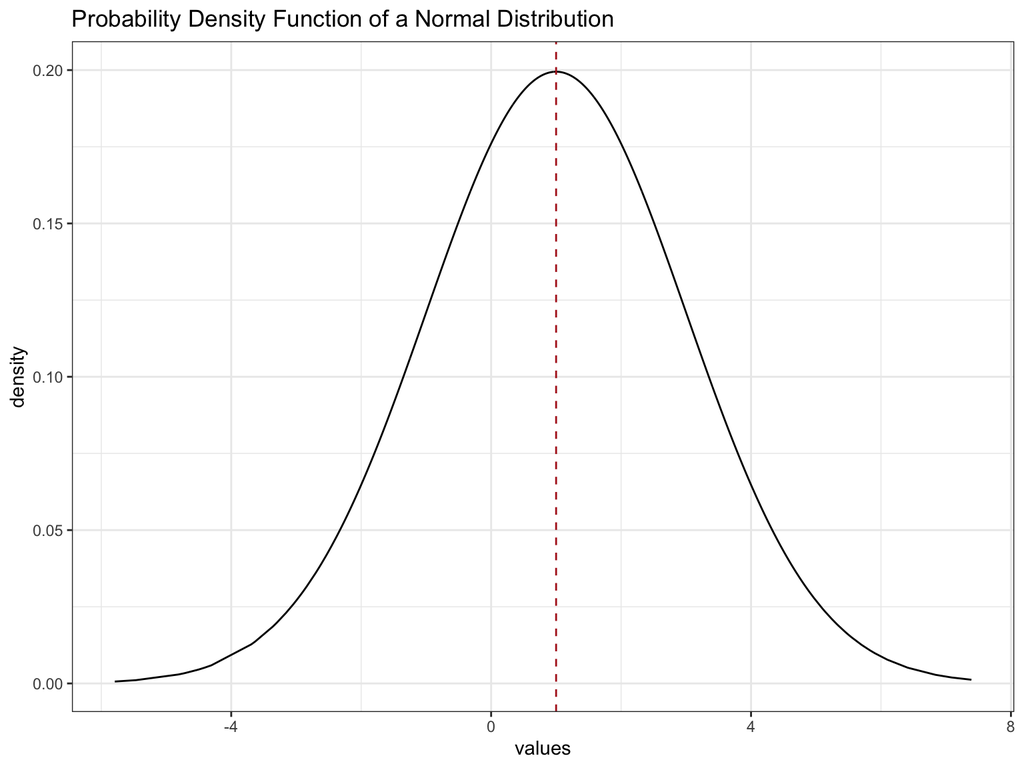

```r
normal_density_graph <- sample1 %>%
  # create a ggplot object
  ggplot() +
  geom_line(mapping = aes(x = values, y = density), col = "black") +
  labs(y = "density", x = "values", title = "Probability Density Function of a Normal Distribution") +
  # add vertical line equal to the mean
  geom_vline(xintercept = 1, col = "firebrick", linetype = "dashed") +
  theme_bw()

normal_density_graph
```

- Extra: compare using a histogram

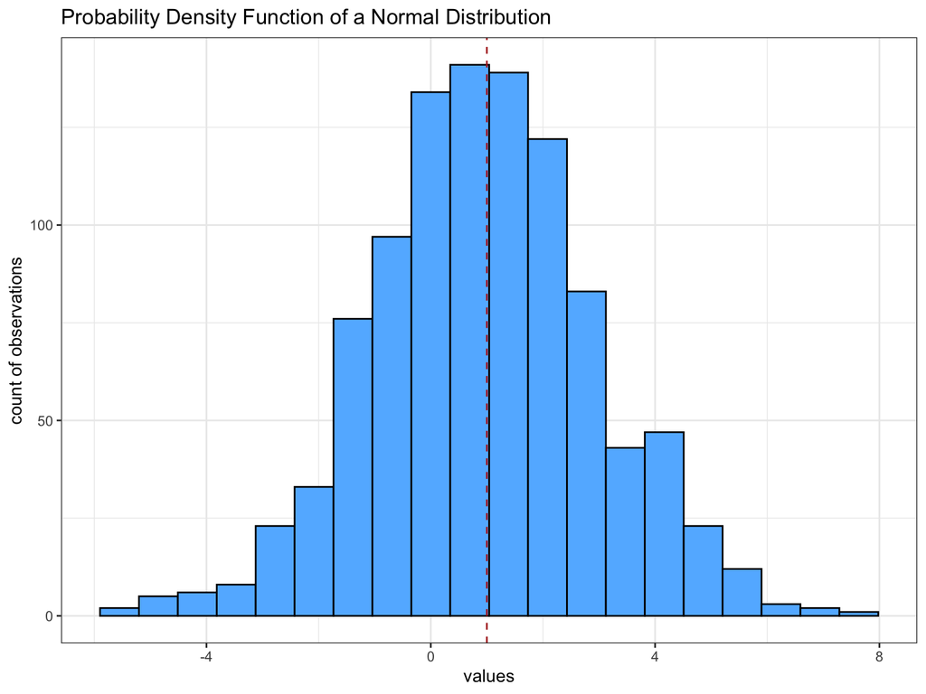

```r
histogram_plot <- sample1 %>%
  # create a ggplot object
  ggplot(mapping = aes(x = values)) +
  geom_histogram(col = "black", fill = "steelblue1", bins = 20) +
  labs(y = "count of observations", x = "values", title = "Probability Density Function of a Normal Distribution") +
  # add vertical line equal to the mean
  geom_vline(xintercept = 1, col = "firebrick", linetype = "dashed") +
  theme_bw()


histogram_plot
```

- Add the normal density line to compare.
- We need to modify the code above to show the histogram, but with the units from the probability density function.
- Note: keep in mind this comparison is between the empirical (observed) distribution from the data, and a theoretical (unobserved)

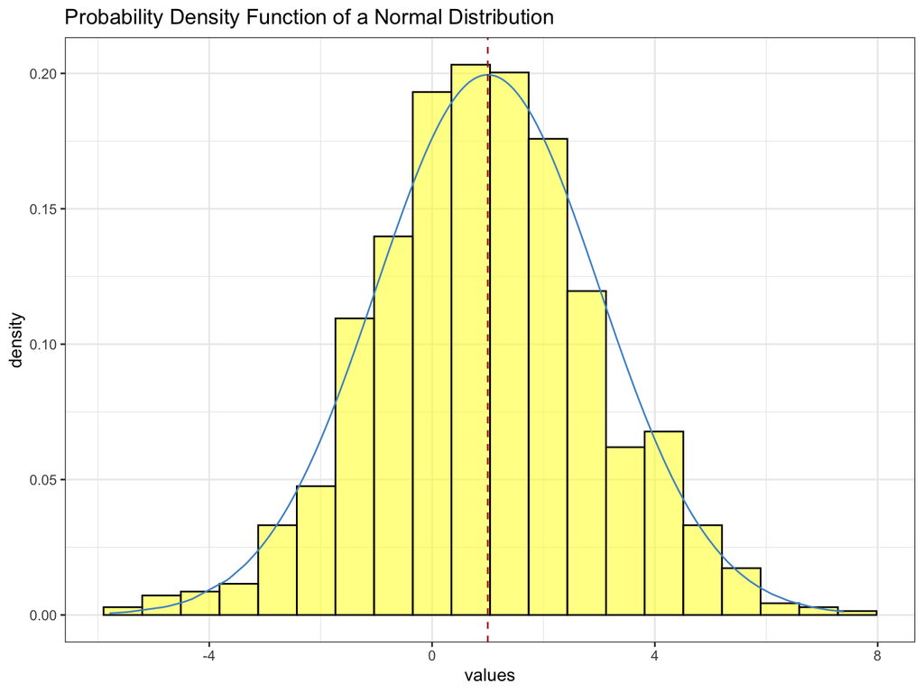

```r
histogram_plot_with_normal_curve <- sample1 %>%
  # create a ggplot object
    # Set the mapping to tell R the y axis is expressed in units from the density function
  ggplot(mapping = aes(x = values, y = ..density..)) +
  # Create the histogram
  geom_histogram(col = "black", fill = "yellow1", bins = 20, alpha = 0.5) +
  # To add the normal curve, we need to specify again the aesthetic mapping
  geom_line(mapping = aes(x = values, y = density), col = "steelblue3") +
  labs(y = "density", x = "values", title = "Probability Density Function of a Normal Distribution") +
  # add vertical line equal to the mean
  geom_vline(xintercept = 1, col = "firebrick", linetype = "dashed") +
  theme_bw()


histogram_plot_with_normal_curve
```

# Example: Fast Food Data

- Let’s load the fast food data. It contains observations on the nutritional content of several items from fast food restaurants in the US.
- Task: build a table of descriptive statistics (mean, median, standard deviation, number of observations, % missing) for a given variable in the data set.

```r
fastfood <- rio::import(file = "fastfood.csv", header = TRUE) %>%
  # store as tibble data frame
  tibble()
# Show data: Slice_sample takes a random sample of size n
fastfood %>%
  slice_sample(n = 5)
```

```
## # A tibble: 5 × 17
##   restaurant  item      calories cal_fat total_fat sat_fat trans_fat cholesterol
##   <chr>       <chr>        <int>   <int>     <int>   <dbl>     <dbl>       <int>
## 1 Subway      "Footlon…      640     160        18       8         0          40
## 2 Subway      "6\"\" B…      580     310        31      11         0          85
## 3 Subway      "Footlon…      740     200        22      10         0          90
## 4 Taco Bell   "Doritos…      490     250        28      10         1          55
## 5 Burger King "Spicy C…      530     333        37       7         0          55
## # ℹ 9 more variables: sodium <int>, total_carb <int>, fiber <int>, sugar <int>,
## #   protein <int>, vit_a <int>, vit_c <int>, calcium <int>, salad <chr>
```

# Functions to compute analysis

- You can use functions to perform more complex tasks than drawing lines.
- Let’s create a function that summarizes a variable from the data set.

```r
descriptive_table <- function(x){
  # Compute the Descriptive Statistics using base R functions
  x_count <- length(x)
  x_miss <- sum(is.na(x))/length(x)
  x_mean <- mean(x, na.rm = TRUE)
  x_median <- median(x, na.rm = TRUE)
  x_sd <- sd(x, na.rm = TRUE)

  # Save output as data frame (tibble object)
  table <- tibble(obs = x_count,
                      miss = x_miss, mean = x_mean,
                      median = x_median, sd = x_sd)

  # Return Table
  return(table)
}
```

- Let’s try our function.

```r
calories <- fastfood$calories
descriptive_table(calories)
```

```
## # A tibble: 1 × 5
##     obs  miss  mean median    sd
##   <int> <dbl> <dbl>  <int> <dbl>
## 1   515     0  531.    490  282.
```

# Apply Functions to Multiple Objects

- Most of the times you build a function because you will use that program (recipe) several times.
- We can use `lapply` to apply a function to list of objects.
- Remember: lists are flexible and can store objects of any class.
- Tip: to access elements of a list we need to use double brackets notation.

```r
# Example:
calories <- fastfood$calories
carbs <- fastfood$total_carb
total_fat <- fastfood$total_fat
# Create a list of Variables
variables <- list(calories, carbs, total_fat)
```

- Show the first element of the list

```r
# Access first element of the list
variables[[1]]
```

[output not shown]

- Apply the function we created to all the elements of the list.
- Note: the output of lapply is also a list.
- lapply syntax: lapply(list, function)

```r
variables_descriptive_tables <- lapply(variables, descriptive_table)
```

- Examine the object. Note each element is a data frame.

```r
bind_rows(variables_descriptive_tables[[1]] %>% mutate(varname = "Calories"),
          variables_descriptive_tables[[2]] %>% mutate(varname = "Carbs"),
          variables_descriptive_tables[[3]] %>% mutate(varname = "Total Fat")) %>%
  # Relocate allows you to change the order of the variables in the data frame
  relocate(varname)
```

```
## # A tibble: 3 × 6
##   varname     obs  miss  mean median    sd
##   <chr>     <int> <dbl> <dbl>  <int> <dbl>
## 1 Calories    515     0 531.     490 282.
## 2 Carbs       515     0  45.7     44  24.9
## 3 Total Fat   515     0  26.6     23  18.4
```

# summarize() and group_by()

- Two powerful `dplyr` functions for data analysis: `group_by` and `summarize`
- group_by() allows you to specify a categorical variable whose categories will create clusters or subsets of the data. Grouping by category.
- summarize() creates a new data frame that uses the grouping variables to summarize the observations in the group.
- Useful summarizing functions, according to the dplyr documentation:
  - Center: mean(), median()
  - Spread: sd(), IQR(), mad()
  - Range: min(), max(), quantile()
  - Position: first(), last(), nth(),
  - Count: n(), n_distinct()
  - Logical: any(), all()

# Example: Data Summary using summarize

- Use summarize to build the descriptive statistics of variable: `calories`

```r
descriptive_stats_calories <- fastfood %>%
  summarize(Mean = mean(calories, na.rm = TRUE),
            SD = sd(calories, na.rm = TRUE),
            Min = min(calories, na.rm = TRUE),
            Percent25 = quantile(calories, probs = 0.25),
            Median = quantile(calories, probs = 0.50),
            Percent75 = quantile(calories, probs = 0.75),
            Max = max(calories, na.rm = TRUE),
            Obs = n())
# Show the Table
descriptive_stats_calories
```

```
## # A tibble: 1 × 8
##    Mean    SD   Min Percent25 Median Percent75   Max   Obs
##   <dbl> <dbl> <int>     <dbl>  <dbl>     <dbl> <int> <int>
## 1  531.  282.    20       330    490       690  2430   515
```

- Tip: Add the variable name to display the table better.

```r
descriptive_stats_calories %>%
  mutate(Variable = "Calories") %>%
  # Function Relocate changes the ordering of the variables
  relocate(Variable, Obs, Mean, SD)
```

```
## # A tibble: 1 × 9
##   Variable   Obs  Mean    SD   Min Percent25 Median Percent75   Max
##   <chr>    <int> <dbl> <dbl> <int>     <dbl>  <dbl>     <dbl> <int>
## 1 Calories   515  531.  282.    20       330    490       690  2430
```

# Example: Data Summary by Category

- Suppose you want to compute the descriptive statistics of the variable calories across restaurants. That is, compare their distributions.
- We can do that by adding `group_by` to our previous code.

```r
descriptive_stats_calories_restaurant <- fastfood %>%
  # Add Grouping Criteria
  group_by(restaurant) %>%
  # Same code as before
  summarize(Mean = mean(calories, na.rm = TRUE),
            SD = sd(calories, na.rm = TRUE),
            Min = min(calories, na.rm = TRUE),
            Percent25 = quantile(calories, probs = 0.25),
            Median = quantile(calories, probs = 0.50),
            Percent75 = quantile(calories, probs = 0.75),
            Max = max(calories, na.rm = TRUE),
            Obs = n())
# Show the Table
descriptive_stats_calories_restaurant %>%
  # Sort the data by highest average calories
  arrange(-Mean)
```

```
## # A tibble: 8 × 9
##   restaurant   Mean    SD   Min Percent25 Median Percent75   Max   Obs
##   <chr>       <dbl> <dbl> <int>     <dbl>  <dbl>     <dbl> <int> <int>
## 1 Mcdonalds    640.  411.   140      380     540       740  2430    57
## 2 Sonic        632.  301.   100      410     570       740  1350    53
## 3 Burger King  609.  290.   190      365     555       760  1550    70
## 4 Arbys        533.  210.    70      360     550       690  1030    55
## 5 Dairy Queen  520.  259.    20      350     485       630  1260    42
## 6 Subway       503.  282.    50      288.    460       740  1160    96
## 7 Taco Bell    444.  184.   140      320     420       575   880   115
## 8 Chick Fil-A  384.  220.    70      220     390       480   970    27
```

# Preview of Confidence Intervals

- Next labs we will explore in more detail statistical inference and confidence intervals.
- For now, just recall the formula to compute a confidence interval on the sample mean.
- Assuming the Central Limit Theorem holds, then sample mean $\bar{x}$ follows a normal distribution.

$$Conf.Int. = (\bar{x}-z^*SE(\bar{x}),
\bar{x}+z^*SE(\bar{x}))$$

where: - $\bar{x}$ is the sample mean - $SE(\bar{x})$ is the standard error of $\bar{x}$ and it is defined as:

$$SE(\bar{x}) = \frac{\sigma_x}{\sqrt
N}$$
- z^* is the critical value of the normal distribution used for inference. For a 95% confidence interval, this is 1.96.

$$Conf.Int. =
(\bar{x}-1.96^*\frac{\sigma_x}{\sqrt N},
\bar{x}+1.96\frac{\sigma_x}{\sqrt N})$$

We can use summarize to compute standard errors, and manually compute the confidence interval of our mean estimates.

```r
z_95 = qnorm(0.975)
z_95
```

```
## [1] 1.959964
```

```r
calories_conf_int <- fastfood %>%
  # Same code as before
  summarize(mean = mean(calories, na.rm = TRUE),
            sd = sd(calories, na.rm = TRUE),
            obs = n()) %>%
  # compute standard errors
  mutate(se = sd/sqrt(obs)) %>%
  # compute confidence interval bounds
  mutate(conf.low = mean - z_95*se,
         conf.high = mean + z_95*se)

# check the output
calories_conf_int
```

```
## # A tibble: 1 × 6
##    mean    sd   obs    se conf.low conf.high
##   <dbl> <dbl> <int> <dbl>    <dbl>     <dbl>
## 1  531.  282.   515  12.4     507.      555.
```

- Extra: use base R `t.test` command to verify the output. (More on this next lab!)

```r
t.test(fastfood$calories)
```

```
##
##  One Sample t-test
##
## data:  fastfood$calories
## t = 42.659, df = 514, p-value < 2.2e-16
## alternative hypothesis: true mean is not equal to 0
## 95 percent confidence interval:
##  506.4621 555.3632
## sample estimates:
## mean of x
##  530.9126
```

# Extra Example: Data Summary Across Variables

- You can do similar analysis and look at descriptive statistics of different variables

```r
descriptive_stats_calories_restaurant <- fastfood %>%
  # Add Grouping Criteria
  group_by(restaurant) %>%
  # Same code as before
  summarize(mean_calories = mean(calories, na.rm = TRUE),
            mean_total_fat = mean(total_fat, na.rm = TRUE),
            mean_trans_fat = mean(trans_fat, na.rm = TRUE),
            mean_total_carbs = mean(total_carb, na.rm = TRUE),
            Obs = n())
# Show
descriptive_stats_calories_restaurant %>%
  arrange(-mean_calories)
```

```
## # A tibble: 8 × 6
##   restaurant  mean_calories mean_total_fat mean_trans_fat mean_total_carbs   Obs
##   <chr>               <dbl>          <dbl>          <dbl>            <dbl> <int>
## 1 Mcdonalds            640.           31.8         0.465              48.8    57
## 2 Sonic                632.           37.6         0.934              47.2    53
## 3 Burger King          609.           36.8         0.864              39.3    70
## 4 Arbys                533.           27.0         0.418              44.9    55
## 5 Dairy Queen          520.           28.9         0.679              38.7    42
## 6 Subway               503.           18.5         0.219              54.7    96
## 7 Taco Bell            444.           20.9         0.257              46.6   115
## 8 Chick Fil-A          384.           16.1         0.0370             28.6    27
```

# Additional functions

**descriptr’s ds_freq_table()**

- This returns a frequency table for categorical and continuous data, returning the frequency, cumulative, frequency, frequency percent, and cumulative frequency percent.

```r
if(!require("descriptr")) {
  install.packages("descriptr")
  library(descriptr)
}
```

```r
ds_freq_table(fastfood, calories)
```

```
##                            Variable: calories
## |-----------------------------------------------------------------------|
## |    Bins     | Frequency | Cum Frequency |   Percent    | Cum Percent  |
## |-----------------------------------------------------------------------|
## |  20  - 502  |    269    |      269      |    52.23     |    52.23     |
## |-----------------------------------------------------------------------|
## | 502  - 984  |    212    |      481      |    41.17     |     93.4     |
## |-----------------------------------------------------------------------|
## | 984  - 1466 |    29     |      510      |     5.63     |    99.03     |
## |-----------------------------------------------------------------------|
## | 1466 - 1948 |     4     |      514      |     0.78     |    99.81     |
## |-----------------------------------------------------------------------|
## | 1948 - 2430 |     1     |      515      |     0.19     |     100      |
## |-----------------------------------------------------------------------|
## |    Total    |    515    |       -       |    100.00    |      -       |
## |-----------------------------------------------------------------------|
```

```r
ds_freq_table(fastfood, calories, bins = 10)
```

```
##                            Variable: calories
## |-----------------------------------------------------------------------|
## |    Bins     | Frequency | Cum Frequency |   Percent    | Cum Percent  |
## |-----------------------------------------------------------------------|
## |  20  - 261  |    76     |      76       |    14.76     |    14.76     |
## |-----------------------------------------------------------------------|
## | 261  - 502  |    193    |      269      |    37.48     |    52.23     |
## |-----------------------------------------------------------------------|
## | 502  - 743  |    155    |      424      |     30.1     |    82.33     |
## |-----------------------------------------------------------------------|
## | 743  - 984  |    57     |      481      |    11.07     |     93.4     |
## |-----------------------------------------------------------------------|
## | 984  - 1225 |    25     |      506      |     4.85     |    98.25     |
## |-----------------------------------------------------------------------|
## | 1225 - 1466 |     4     |      510      |     0.78     |    99.03     |
## |-----------------------------------------------------------------------|
## | 1466 - 1707 |     3     |      513      |     0.58     |    99.61     |
## |-----------------------------------------------------------------------|
## | 1707 - 1948 |     1     |      514      |     0.19     |    99.81     |
## |-----------------------------------------------------------------------|
## | 1948 - 2189 |     0     |      514      |      0       |    99.81     |
## |-----------------------------------------------------------------------|
## | 2189 - 2430 |     1     |      515      |     0.19     |     100      |
## |-----------------------------------------------------------------------|
## |    Total    |    515    |       -       |    100.00    |      -       |
## |-----------------------------------------------------------------------|
```